# task1

2023-03-13

```r
library(readxl)
library(dplyr)
```

```r
df <- read_xls("PRESTIGE (1).xls")
head(df)
```

```
## # A tibble: 6 × 5
##   ...1                 PRESTIGE SUICIDE INCOME SCHOOL
##   <chr>                   <dbl>   <dbl>  <dbl>  <dbl>
## 1 Accountant&Auditors        82    23.8   3977   14.4
## 2 Architects                 90    37.5   5509   16
## 3 Authors,Editors,Repo       76    37     4303   15.6
## 4 Chemists                   90    20.7   4091   16
## 5 Clergymen                  87    10.6   2410   16
## 6 College presid.,prof       93    14.2   4366   16
```

```r
library(ggplot2)
library(GGally)
```

Посмотрим на данные.

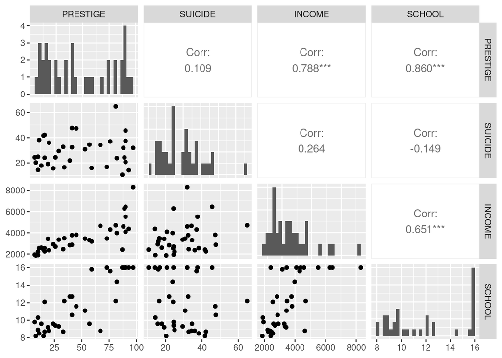

```r
df %>% select(PRESTIGE, SUICIDE, INCOME, SCHOOL) %>%
  ggpairs(diag=list(continuous = "barDiag"))
```

1. Построим линейную регрессионную модель. Хотим узнать как престиж, доходы и образованность влияют на суицидальность.

```r
model = lm(SUICIDE~PRESTIGE+INCOME+SCHOOL, data=df)
summary(model)
```

```
##
## Call:
## lm(formula = SUICIDE ~ PRESTIGE + INCOME + SCHOOL, data = df)
##
## Residuals:
##     Min      1Q  Median      3Q     Max
## -14.430  -7.986  -2.164   6.675  25.727
##
## Coefficients:
##              Estimate Std. Error t value Pr(>|t|)
## (Intercept) 48.515996  10.567091   4.591 6.49e-05 ***
## PRESTIGE     0.208407   0.135707   1.536  0.13444
## INCOME       0.003414   0.002023   1.687  0.10125
## SCHOOL      -3.472824   1.137284  -3.054  0.00453 **
## ---
## Signif. codes:  0 '***' 0.001 '**' 0.01 '*' 0.05 '.' 0.1 ' ' 1
##
## Residual standard error: 10.37 on 32 degrees of freedom
## Multiple R-squared:  0.2995, Adjusted R-squared:  0.2339
## F-statistic: 4.562 on 3 and 32 DF,  p-value: 0.009039
```

Столбец Estimate демонстрирует, что чем ниже уровень образования, тем выше суицидальность, остальные два признака кажутся незначимыми. Столбец Pr(>|t|) отражает p-value проверки гипотезы незначивомисти признаков в модели. С увровнем значимости 0.5 только SCHOOL значим.

F-statistic p-value меньше 0.5, модель значима.

Теперь стандартизируем коэффициенты регрессии.

```r
library(lm.beta)
```

```r
model.st <- lm.beta(model)
summary(model.st)
```

```
##
## Call:
## lm(formula = SUICIDE ~ PRESTIGE + INCOME + SCHOOL, data = df)
##
## Residuals:
##     Min      1Q  Median      3Q     Max
## -14.430  -7.986  -2.164   6.675  25.727
##
## Coefficients:
##              Estimate Standardized Std. Error t value Pr(>|t|)
## (Intercept) 48.515996           NA  10.567091   4.591 6.49e-05 ***
## PRESTIGE     0.208407     0.550721   0.135707   1.536  0.13444
## INCOME       0.003414     0.407192   0.002023   1.687  0.10125
## SCHOOL      -3.472824    -0.887573   1.137284  -3.054  0.00453 **
## ---
## Signif. codes:  0 '***' 0.001 '**' 0.01 '*' 0.05 '.' 0.1 ' ' 1
##
## Residual standard error: 10.37 on 32 degrees of freedom
## Multiple R-squared:  0.2995, Adjusted R-squared:  0.2339
## F-statistic: 4.562 on 3 and 32 DF,  p-value: 0.009039
```

Появляется новый столбец Standardized.

2. Посмотрим на корреляционную матрицу между коэффициентами модели.

```r
vcov(model)
```

```
##               (Intercept)      PRESTIGE        INCOME        SCHOOL
## (Intercept) 111.663421416  1.0573458571 -9.030411e-03 -1.066340e+01
## PRESTIGE      1.057345857  0.0184165152 -1.619156e-04 -1.145112e-01
## INCOME       -0.009030411 -0.0001619156  4.092835e-06  1.959521e-04
## SCHOOL      -10.663395955 -0.1145111663  1.959521e-04  1.293414e+00
```

```r
cov2cor(vcov(model))
```

```
##             (Intercept)   PRESTIGE      INCOME      SCHOOL
## (Intercept)   1.0000000  0.7373232 -0.42241560 -0.88730169
## PRESTIGE      0.7373232  1.0000000 -0.58975680 -0.74195122
## INCOME       -0.4224156 -0.5897568  1.00000000  0.08516654
## SCHOOL       -0.8873017 -0.7419512  0.08516654  1.00000000
```

(Как строить эллипс?)

3. Попробуем в ручную уменьшить число признаков, исходя из изученных характеристик.

```r
library(olsrr)
```

```r
ols_vif_tol(model)
```

```
##   Variables Tolerance      VIF
## 1  PRESTIGE 0.1702093 5.875118
## 2    INCOME 0.3759101 2.660210
## 3    SCHOOL 0.2590894 3.859671
```

Меньшее значние Tolerance у престижности професии.

Вычислим частные корреляции. [Zero Order - корреляция Пирсона между зависимым и независимым признаком; Partial - частная корреляци между; Part - получастная корреляция.]

```r
ols_correlations(model)
```

```
##                Correlations
## -------------------------------------------
## Variable    Zero Order    Partial     Part
## -------------------------------------------
## PRESTIGE         0.109      0.262     0.227
## INCOME           0.264      0.286     0.250
## SCHOOL          -0.149     -0.475    -0.452
## -------------------------------------------
```

Большая частная корреляция у SCHOOL, т.е. менее предпочтительно ее исключать.

Удалим PRESTIGE из модели

```r
model.p = lm(SUICIDE~INCOME+SCHOOL, data=df)
model.st.p <- lm.beta(model.p)
summary(model.st.p)
```

```
##
## Call:
## lm(formula = SUICIDE ~ INCOME + SCHOOL, data = df)
##
## Residuals:
##     Min      1Q  Median      3Q     Max
## -15.285  -7.730  -2.053   6.374  30.152
##
## Coefficients:
##              Estimate Standardized Std. Error t value Pr(>|t|)
## (Intercept) 36.550755           NA   7.283936   5.018 1.75e-05 ***
## INCOME       0.005246     0.625744   0.001667   3.147  0.00349 **
## SCHOOL      -2.176982    -0.556386   0.778031  -2.798  0.00852 **
## ---
## Signif. codes:  0 '***' 0.001 '**' 0.01 '*' 0.05 '.' 0.1 ' ' 1
##
## Residual standard error: 10.58 on 33 degrees of freedom
## Multiple R-squared:  0.2479, Adjusted R-squared:  0.2023
## F-statistic: 5.439 on 2 and 33 DF,  p-value: 0.009085
```

Ранее было (с всеми признаками): Residual standard error: 10.37 on 32 degrees of freedom Multiple R-squared: 0.2995, Adjusted R-squared: 0.2339 F-statistic: 4.562 on 3 and 32 DF, p-value: 0.009039

Модель все еще значима.

```r
ols_vif_tol(model)
```

```
##   Variables Tolerance      VIF
## 1  PRESTIGE 0.1702093 5.875118
## 2    INCOME 0.3759101 2.660210
## 3    SCHOOL 0.2590894 3.859671
```

```r
ols_correlations(model)
```

```
##                Correlations
## -------------------------------------------
## Variable    Zero Order    Partial     Part
## -------------------------------------------
## PRESTIGE         0.109      0.262     0.227
## INCOME           0.264      0.286     0.250
## SCHOOL          -0.149     -0.475    -0.452
## -------------------------------------------
```

Удалим INCOME из модели.

```r
model.p.i = lm(SUICIDE~SCHOOL, data=df)
model.st.p.i <- lm.beta(model.p.i)
summary(model.st.p.i)
```

```
##
## Call:
## lm(formula = SUICIDE ~ SCHOOL, data = df)
##
## Residuals:
##     Min      1Q  Median      3Q     Max
## -16.094 -10.123  -1.798   5.688  35.889
##
## Coefficients:
##             Estimate Standardized Std. Error t value Pr(>|t|)
## (Intercept)  36.0287           NA     8.1801   4.404   0.0001 ***
## SCHOOL       -0.5834      -0.1491     0.6635  -0.879   0.3854
## ---
## Signif. codes:  0 '***' 0.001 '**' 0.01 '*' 0.05 '.' 0.1 ' ' 1
##
## Residual standard error: 11.89 on 34 degrees of freedom
## Multiple R-squared:  0.02224,    Adjusted R-squared:  -0.006522
## F-statistic: 0.7732 on 1 and 34 DF,  p-value: 0.3854
```

Такая модель незначима. Следовательно, рекомендуемая модель при зависимом признаке SUICIDE включает в себя независиммые признаки SCHOOL и INCOME.